# Práctica 9. Reconstrucción filogenética

Última actualización:

16 de mayo de 2026

# Introducción y preparación

Aunque existen muy buenos programas para inferir filogenias fuera del entorno de R (es decir, para el terminal de Bash), utilizar las herramientas en R tiene la ventaja de poder representar los árboles, manipularlos y extraer información de ellos con toda la flexibilidad que permite un lenguaje de programación.

Programas como RAxML o IQtree producen los resultados en forma de archivos de texto con formato Newick o NEXUS; en cambio, en R, los árboles serán objetos de clase `phylo`, que pueden también ser exportados como archivos de texto con formato Newick con la función `write.tree()` del paquete `ape`. Este paquete será cargado automáticamente cuando carguemos el paquete `phangorn`, que proporciona las principales funciones para inferencia filogenética:

```r
install.packages('phangorn')
```

```r
library('phangorn')
```

# Objetivos

Obtener una filogenia calibrada de homininos y algunos primates, a partir de secuencias mitocondriales.

# Datos

[Pinchando aquí](https://aulavirtual.uv.es/pluginfile.php/6009204/mod_resource/content/3/mtDNA.fasta) descargamos un alineamiento en formato FASTA de 42 cromosomas mitocondriales completos de:

- 1 gorila
- 4 chimpancés
- 4 bonobos
- 1 *Homo heidelbergensis* (de hace unos 400.000 años)
- 4 humanos denisovanos (de hace entre 30.000 y 110.000 años)
- 19 humanos neandertales (de hace entre 30.000 y 180.000 años)
- 9 humanos anatómicamente modernos (actuales).

El archivo `mtDNA.fasta` debe estar guardado en la carpeta de `data` y, a continuación, lo cargamos en un objeto de R de clase `phyDat`:

```r
mtdna <- read.phyDat('../../data/mtDNA.fasta', format = 'fasta')
```

Puedes usar la **consola** de R para echarle un vistazo, por ejemplo con la función `glance()`, o incluso para generar una imagen del alineamiento con `image()`. Si tienes instalado el paquete `Biostrings` (de Bioconductor), puedes crear un objeto de classe `DNAStringSet` con `as.StringSet(mtDNA)`, al que se le pueden aplicar muchas otras funciones.

```r
glance(mtdna)
```

```
  nseq nchar unique_site_pattern parsimony_informative_sites const_sites
1   42 16603                 974                        2047       13482
```

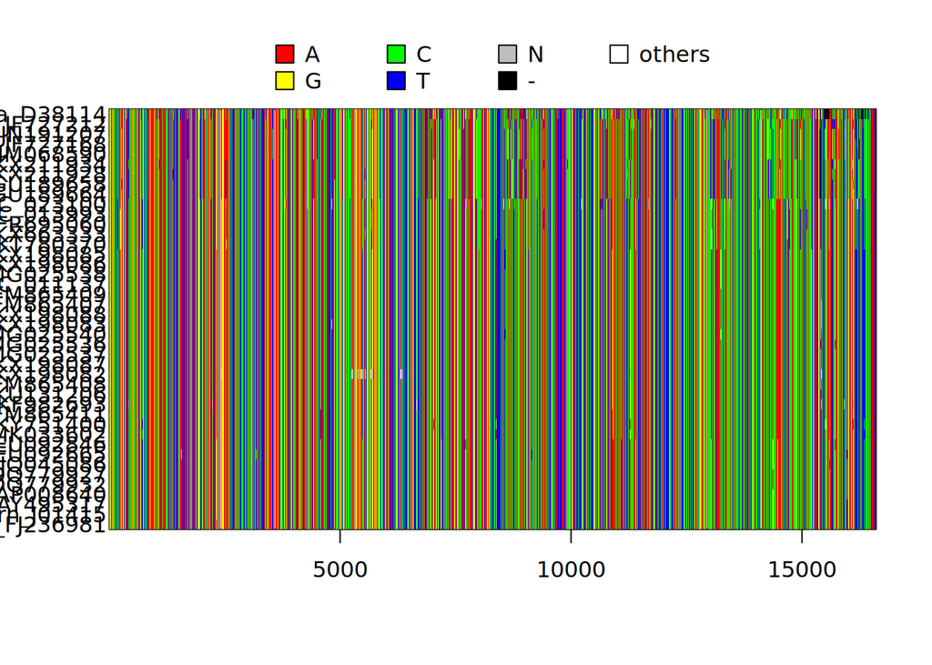

```r
image(mtdna)
```

```r
library('Biostrings')
```

```r
as.StringSet(mtdna)
```

```
DNAStringSet object of length 42:
     width seq                                              names
 [1] 16603 GATTACACATGCAAGCATCCCCG...CCTTTCTATTAACTCTTAGTAG G.gorilla_D38114
 [2] 16603 GATTACACATGCAAGCATCCCCG...CCTTTCTATTAGCTCTTAGTAA P.troglodytes_JF7...
 [3] 16603 GATTACACATGCAAGCATCCCCG...CCTTTCTATTAGCCCTTAGTAA P.troglodytes_JN1...
 [4] 16603 GATTACACATGCAAGCATCCCCG...CCTTTCTATTAGCCCTTAGTAA P.troglodytes_JF7...
 [5] 16603 GATTACACATGCAAGCATCCCCG...CCTTTCTATTAGCCCTTAGTAA P.troglodytes_HM0...
 ...   ... ...
[38] 16603 GATTACACATGCAAGCATCCCCG...CCTTTCTATTAGCTCTTAGTAA H.s.modern_DQ779932
[39] 16603 GATTACACATGCAAGCATCCCCG...CCTTTCTATTAGCTCTTAGTAA H.s.modern_AP008640
[40] 16603 GATTACACATGCAAGCATCCCCG...CCTTTCTATTAGCTCTTAGTAA H.s.modern_AY495317
[41] 16603 GATTACACATGCAAGCATCCCCG...CCTTTCTATTAGCTCTTAGTAA H.s.modern_J01415
[42] 16603 GATTACACATGCAAGCATCCCCG...CCTTTCTATTAGCTCTTAGTAA H.s.modern_FJ236981
```

**Ejercicio 1**

¿Puedes confirmar el número de secuencias? ¿Qué longitud tiene el alineamiento? ¿Qué función usarías para extraer los nombres de las secuencias?

Gracias al DNAStringSet podemos ver que la longitud de la lista es de **42**, lo que se corresponde con el número de **secuencias**, y la longitud del alineamiento es de **16603pb**.

Por su parte, para extraer el nombre de las secuencias y la especie de la que se han obtenido podemos usar la función `names()`:

```r
names(mtdna)
```

```
 [1] "G.gorilla_D38114"            "P.troglodytes_JF727212"
 [3] "P.troglodytes_JN191207"      "P.troglodytes_JF727168"
 [5] "P.troglodytes_HM068590"      "P.paniscus_KX211934"
 [7] "P.paniscus_KX211928"         "P.paniscus_GU189658"
 [9] "P.paniscus_GU189664"         "H.heidelbergensis_NC_023100"
[11] "H.s.denisova_NC_013993"      "H.s.denisova_FR695060"
[13] "H.s.denisova_KX663333"       "H.s.denisova_KT780370"
[15] "H.s.neandertal_KX198085"     "H.s.neandertal_KX198086"
[17] "H.s.neandertal_MG025538"     "H.s.neandertal_NC_011137"
[19] "H.s.neandertal_FM865409"     "H.s.neandertal_FM865407"
[21] "H.s.neandertal_KX198088"     "H.s.neandertal_KX198083"
[23] "H.s.neandertal_MG025540"     "H.s.neandertal_MG025536"
[25] "H.s.neandertal_MG025537"     "H.s.neandertal_KX198087"
[27] "H.s.neandertal_KX198082"     "H.s.neandertal_FM865408"
[29] "H.s.neandertal_KU131206"     "H.s.neandertal_KF982693"
[31] "H.s.neandertal_FM865411"     "H.s.neandertal_KY751400"
[33] "H.s.neandertal_MK033602"     "H.s.modern_EU092846"
[35] "H.s.modern_EU092665"         "H.s.modern_JQ045086"
[37] "H.s.modern_DQ779927"         "H.s.modern_DQ779932"
[39] "H.s.modern_AP008640"         "H.s.modern_AY495317"
[41] "H.s.modern_J01415"           "H.s.modern_FJ236981"
```

# Árboles basados en distancias

Los árboles NJ y UPGMA pueden proporcionar una idea rápida de cómo podría ser la relación filogenética entre las secuencias pero, al ser métodos basados en distancias, primero necesitamos calcularlas. Podemos hacerlo en el mismo paso en el que generamos el árbol, con: `nj(dist.ml(mtdna))`; o bien, hacerlo en dos pasos: guardar la matriz de distancias en un objeto de clase `dist`, y después generar los árboles.

La función `dist.ml()` (de `phangorn`) solo ofrece un par de modelos de evolución de nucleótidos para estimar distancias: F81 y JC69 (para proteínas ofrece 17 modelos). En cambio, la función `dist.dna()` de `ape` (que no se aplica sobre objetos `phyDat`, sino `DNAbin`) ofrece algunas opciones más. Sin embargo, en el fondo los métodos NJ y UPGMA son sólo heurísticos rápidos, por lo que no nos hace falta usar distancias de alta precisión.

Vamos a hacerlo con el método de 2 pasos:

```r
distancias <- dist.ml(mtdna, model = 'F81')
mt_nj    <- NJ(distancias)
mt_upgma <- upgma(distancias)
```

**Ejercicio 2**

- ¿De qué clase son los objetos `mt_nj` y `mt_upgma`?

  ```r
  class(mt_nj)
  ```

  ```
  [1] "phylo"
  ```

  ```r
  class(mt_upgma)
  ```

  ```
  [1] "phylo"
  ```

- Consulta la estructura de estos objetos (`str(mt_nj)`).

  ```r
  str(mt_nj)
  ```

  ```
  List of 4
   $ edge       : int [1:81, 1:2] 47 47 54 54 53 53 52 52 51 51 ...
   $ edge.length: num [1:81] 6.03e-05 5.20e-08 -4.37e-08 4.37e-08 8.51e-08 ...
   $ tip.label  : chr [1:42] "G.gorilla_D38114" "P.troglodytes_JF727212" "P.troglodytes_JN191207" "P.troglodytes_JF727168" ...
   $ Nnode      : int 40
   - attr(*, "class")= chr "phylo"
   - attr(*, "order")= chr "postorder"
  ```

  ```r
  str(mt_upgma)
  ```

  ```
  List of 4
   $ edge       : int [1:82, 1:2] 63 63 49 49 48 48 59 59 55 55 ...
   $ edge.length: num [1:82] 0.00127 0.00127 0.001422 0.000151 0.011063 ...
   $ tip.label  : chr [1:42] "G.gorilla_D38114" "P.troglodytes_JF727212" "P.troglodytes_JN191207" "P.troglodytes_JF727168" ...
   $ Nnode      : int 41
   - attr(*, "class")= chr "phylo"
   - attr(*, "order")= chr "postorder"
  ```

- Represéntalos gráficamente (`plot(mt_nj)`) y consulta la ayuda de la función `plot.phylo()` para saber qué opciones de representación gráfica tienes.

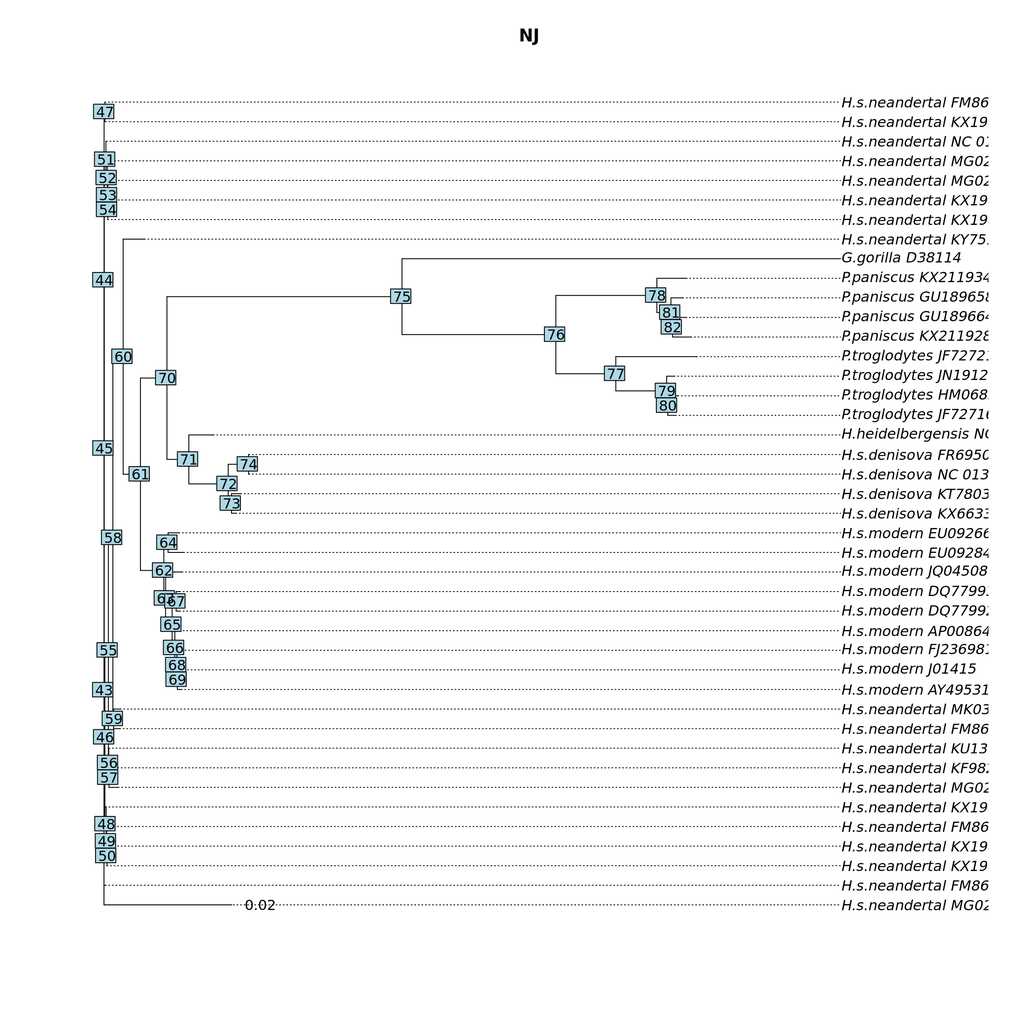

  ```r
  plot(mt_nj, align.tip.label = TRUE, main = 'NJ')
  add.scale.bar()
  nodelabels()
  ```

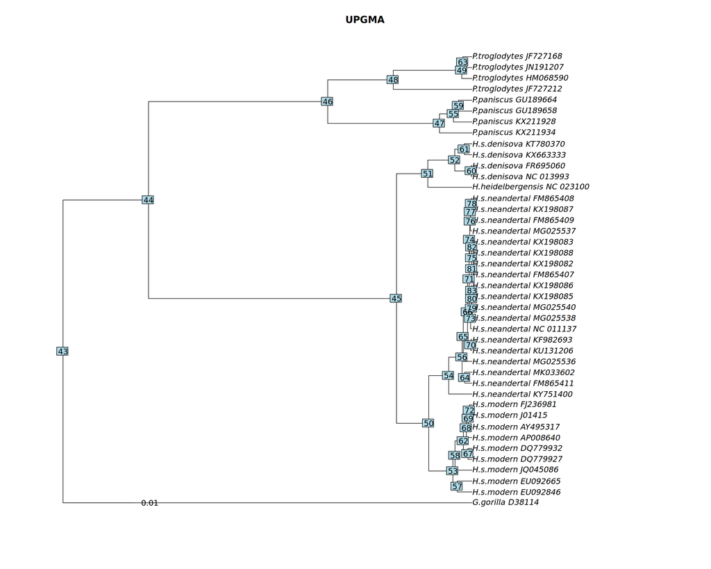

  ```r
  plot(mt_upgma, align.tip.label = TRUE, main = 'UPGMA')
  add.scale.bar()
  nodelabels()
  ```

- Para qué sirven las funciones `add.scale.bar()` y `axisPhylo()`?

  La función `add.scale.bar()` agrega una barra horizontal en la que se indica la escala de las longitudes de las ramas. De esta forma, podemos saber la distancia genética entre las secuencias y cuánto difieren entre ellas.

  Por su parte, `axisPhylo()` añade un eje con escala numérica al lado del árbol filogenético, mostrando los valores de distancia acumulados desde la raíz.

# Enraizar

## Escogiendo el nodo

El árbol `mt_nj` no está enraizado. Se puede comprobar con `is.rooted()`:

```r
is.rooted(mt_nj)
```

```
[1] FALSE
```

Por lo que tenemos un par de opciones para enraizarlo. Una de ellas es `root()`, función en la que debemos especificar o bien el *outgroup* o bien el **nodo** interno en el que queremos situar la raíz. Para saber cómo identificar los nodos internos, podemos incluir la función `nodelabels()` en el chunk de R del `plot(mt_nj)` arriba.

Así vemos que, por ejemplo, el nodo 75 parece ser el ancestro común entre gorilas y chimpancés y, por tanto, también de los humanos. Entonces lo designamos como raíz:

```r
mt_nj_rooted <- root(mt_nj, node = 75)
```

## Con un *outgroup*

La numeración de los nodos internos siempre sigue a la de las hojas (o puntas) del árbol. El orden es caprichoso y después de enraizar, lo que era el 75 en `mt_nj` ahora será el 43 en `mt_nj_rooted`:

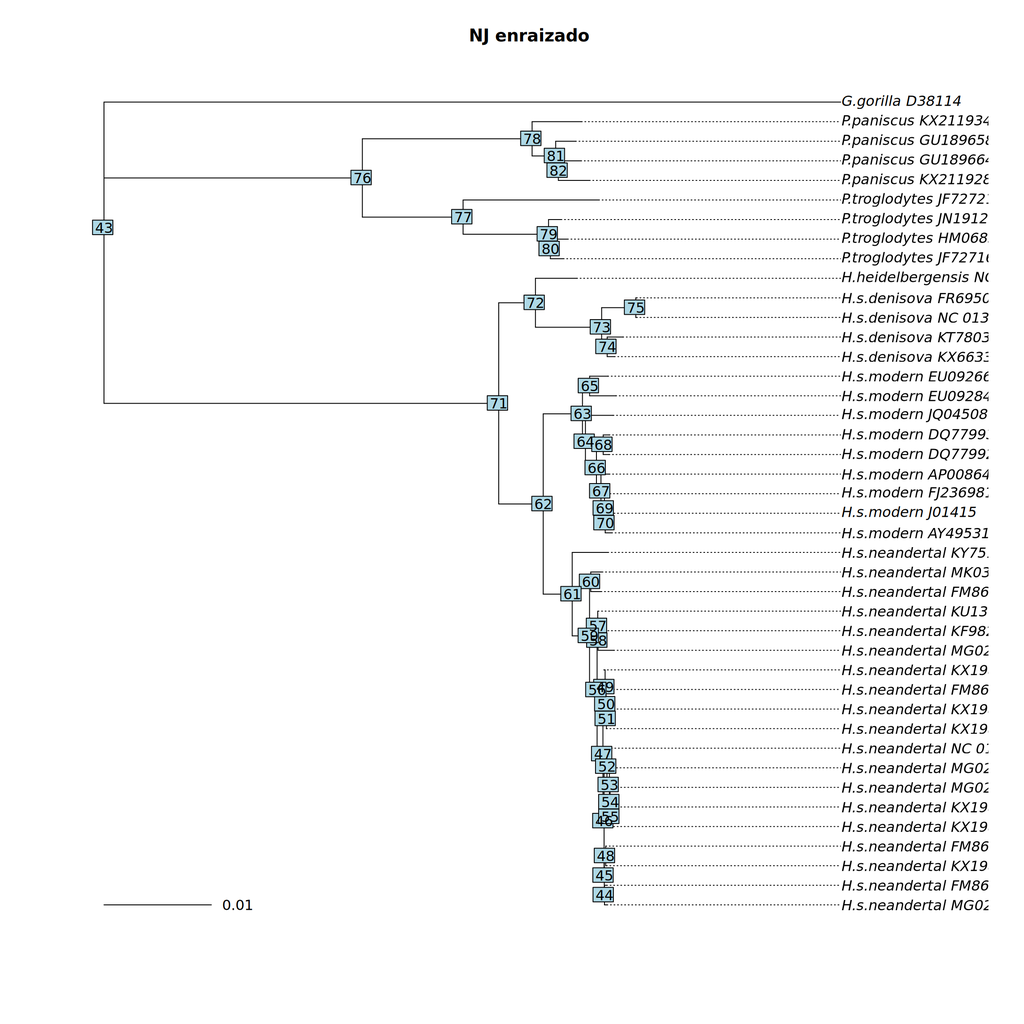

```r
plot(mt_nj_rooted, align.tip.label = TRUE, main = 'NJ enraizado')
add.scale.bar()
nodelabels()
```

Es por eso, para garantizar que el enraizado no dependa de la numeración, lo más seguro es usar el nombre del *outgroup*:

```r
# Debería dar el mismo resultado:
mt_nj_rooted <- root(mt_nj, outgroup = 'G.gorilla_D38114')
```

## En el punto medio

Como se puede ver en la representación del árbol enraizado de arriba (`plot(mt_nj_rooted)`), no todas las hojas del árbol están a la misma altura. El punto exacto en el que se sitúa la raíz en una rama es arbitrario y `root()` no se esfuerza mucho en intentar que el árbol parezca ultramétrico. La otra opción es la función `midpoint()`, que escoge la posición de la raíz para que el árbol esté más equilibrado:

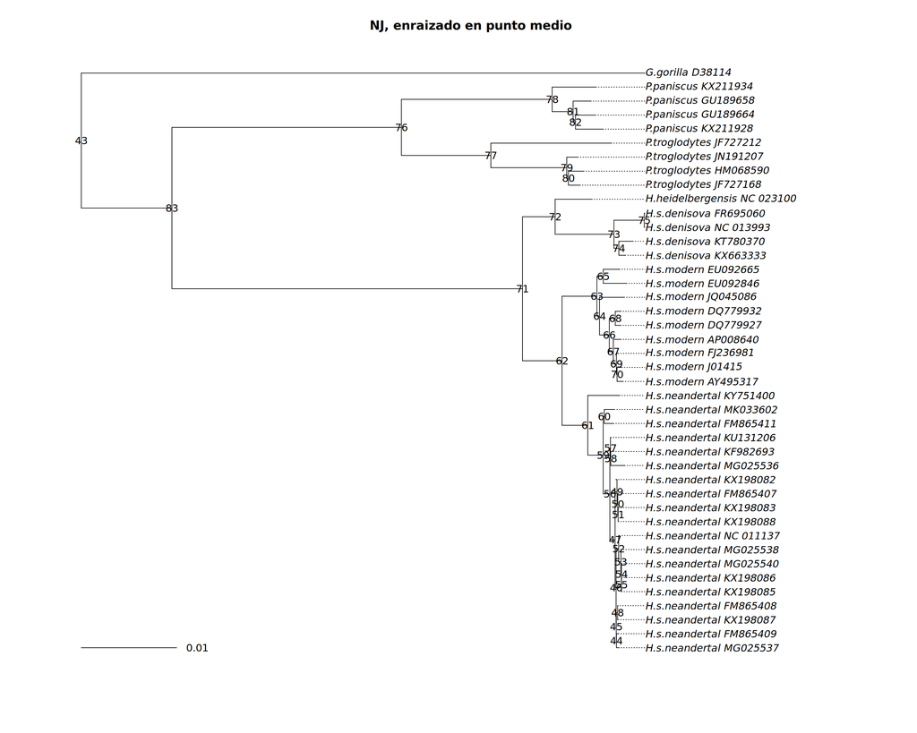

```r
# Esto sobreescribe el objeto anterior:
mt_nj_rooted <- midpoint(mt_nj)
plot(mt_nj_rooted, align.tip.label = TRUE, main = 'NJ, enraizado en punto medio')
nodelabels(frame = 'none')
add.scale.bar()
```

## Con datación de hojas

El enraizado en punto medio asume que todas las hojas son contemporáneas, como sucede en muchos casos. Pero, en nuestros datos tenemos secuencias contemporáneas y también arcaicas. En el apéndice encontrarás referencias sobre las edades estimadas de esas secuencias. Conociendo estas edades, podemos aplicar un método de enraizado llamado *root-to-tip regression*, mediante la función `rtt()` de `ape`.

Lo primero es crear un vector de *fechas* (o edades) para todas las hojas del árbol. Podemos expresar las edades de las secuencias arcaicas como el número (negativo) de años que hace que dejaron de evolucionar. Para saber el orden en que debemos especificar las edades, podemos usar `mt_nj$tip.label`.

```r
fechas <- c(0, 0, 0, 0, 0, 0, 0, 0, 0,
            -400000,
            -39000, -50000, -110000, -110000,
            -39820, -40096, -38515, -38310, -39000, -40000, -41210,
            -42430, -42540, -43230, -43780, -44290, -44770, -49000,
            -50000, -82752, -65000, -122287, -110450,
            0, 0, 0, 0, 0, 0, 0, 0, 0)
# Observa que hay que asignar el resultado de setNames() a "fechas"
fechas <- setNames(fechas, mt_nj$tip.label)
fechas
```

```
           G.gorilla_D38114      P.troglodytes_JF727212
                          0                           0
     P.troglodytes_JN191207      P.troglodytes_JF727168
                          0                           0
     P.troglodytes_HM068590         P.paniscus_KX211934
                          0                           0
        P.paniscus_KX211928         P.paniscus_GU189658
                          0                           0
        P.paniscus_GU189664 H.heidelbergensis_NC_023100
                          0                     -400000
     H.s.denisova_NC_013993       H.s.denisova_FR695060
                     -39000                      -50000
      H.s.denisova_KX663333       H.s.denisova_KT780370
                    -110000                     -110000
    H.s.neandertal_KX198085     H.s.neandertal_KX198086
                     -39820                      -40096
    H.s.neandertal_MG025538    H.s.neandertal_NC_011137
                     -38515                      -38310
    H.s.neandertal_FM865409     H.s.neandertal_FM865407
                     -39000                      -40000
    H.s.neandertal_KX198088     H.s.neandertal_KX198083
                     -41210                      -42430
    H.s.neandertal_MG025540     H.s.neandertal_MG025536
                     -42540                      -43230
    H.s.neandertal_MG025537     H.s.neandertal_KX198087
                     -43780                      -44290
    H.s.neandertal_KX198082     H.s.neandertal_FM865408
                     -44770                      -49000
    H.s.neandertal_KU131206     H.s.neandertal_KF982693
                     -50000                      -82752
    H.s.neandertal_FM865411     H.s.neandertal_KY751400
                     -65000                     -122287
    H.s.neandertal_MK033602         H.s.modern_EU092846
                    -110450                           0
        H.s.modern_EU092665         H.s.modern_JQ045086
                          0                           0
        H.s.modern_DQ779927         H.s.modern_DQ779932
                          0                           0
        H.s.modern_AP008640         H.s.modern_AY495317
                          0                           0
          H.s.modern_J01415         H.s.modern_FJ236981
                          0                           0
```

A continuación se escoge la posición de la raíz que optimiza la regresión entre distancia de raíz a puntas y edades de las puntas ([Rambaut et al. 2016](https://aulavirtual.uv.es/pluginfile.php/6009204/mod_resource/content/3/guio-es.html#ref-Rambaut2016)).

```r
mt_nj_rtt <- rtt(mt_nj, tip.dates = fechas, objective = 'rms')
```

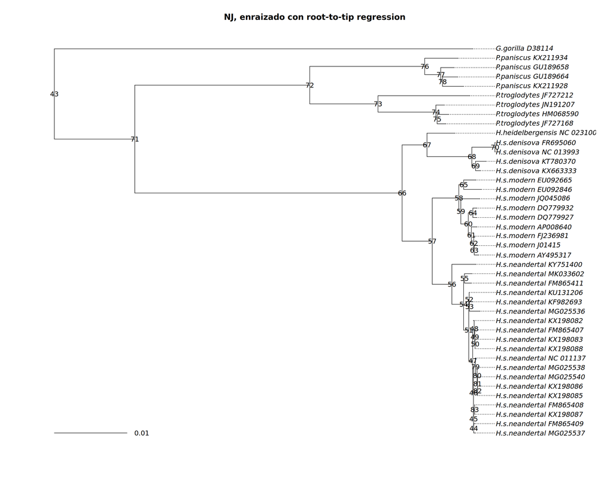

```r
plot(mt_nj_rtt, align.tip.label = TRUE, main = 'NJ, enraizado con root-to-tip regression')
nodelabels(frame = 'none')
add.scale.bar()
```

**Ejercicio 3**

- ¿Se corresponden bien las distancias evolutivas estimadas con las dataciones?

  No, hay ramas que han acumulado cambios que deberían haber quedado más desplazadas hacia atrás.
- ¿Qué secuencias crees que se ajustan menos a su supuesta edad?

  Los humanos denisovanos, por ejemplo, que datan de hace 30.000 a 110.000 años y, por tanto, deberían haber dejado de acumular mutaciones mucho más tiempo atrás del que se distingue en el árbol.
- ¿Qué razones puede haber para que la edad de una secuencia no se corresponda con la cantidad de cambios que ha acumulado?

  Puede ser que las dataciones moleculares no sean fiables o haya errores en las muestras arqueológicas. Aunque también es posible que el método estadístico utilizado en la corrección de errores de la datación no haya sido el más adecuado par algunas muestras, de modo que haya ramas más largas de lo realistamente posible.

# Distancias

El objeto `distancias`, creado anteriormente, puede usarse para conocer la cantidad estimada de cambios entre los cromosomas mitocondriales de dos grupos, por ejemplo, humanos y neandertales. Sin embargo, los objetos de clase `dist` son incómodos, por lo que podemos obtener una simple matriz fácilmente:

```r
distMat <- as.matrix(distancias)
```

Aprovechando que los nombres de las secuencias tienen una estructura coherente, podemos usar `startsWith()` para seleccionar a los humanos modernos, a los neandertales, a los denisovanos, etc.:

```r
# Esto son vectores lógicos que podemos usar después para seleccionar filas
# y columnas de la matriz de distancias.
modernos     <- startsWith(colnames(distMat), 'H.s.modern')
neandertales <- startsWith(colnames(distMat), 'H.s.neandertal')
denisovanos  <- startsWith(colnames(distMat), 'H.s.denisova')
chimpances   <- startsWith(colnames(distMat), 'P.troglodytes')
bonobos      <- startsWith(colnames(distMat), 'P.paniscus')
```

Por tanto, la distancia media estimada entre humanos y neandertales se puede obtener como:

```r
mean(distMat[modernos, neandertales])
```

```
[1] 0.01214282
```

**Ejercicio 4**

- Calcula las distancias medias entre todos los grupos.

  ```r
  mean(distMat[modernos, denisovanos])
  ```

  ```
  [1] 0.02250501
  ```

  ```r
  mean(distMat[modernos, chimpances])
  ```

  ```
  [1] 0.09104153
  ```

  ```r
  mean(distMat[modernos, bonobos])
  ```

  ```
  [1] 0.09239182
  ```

  ```r
  mean(distMat[neandertales, denisovanos])
  ```

  ```
  [1] 0.02201398
  ```

  ```r
  mean(distMat[neandertales, chimpances])
  ```

  ```
  [1] 0.09041225
  ```

  ```r
  mean(distMat[neandertales, bonobos])
  ```

  ```
  [1] 0.09089352
  ```

  ```r
  mean(distMat[denisovanos, chimpances])
  ```

  ```
  [1] 0.09129525
  ```

  ```r
  mean(distMat[denisovanos, bonobos])
  ```

  ```
  [1] 0.09297814
  ```

  ```r
  mean(distMat[chimpances, bonobos])
  ```

  ```
  [1] 0.04059035
  ```

- ¿Cuántas veces mayor es la distancia entre humanos y chimpancés que entre humanos y neandertales?

  ```r
  mean(distMat[modernos, chimpances]) / mean(distMat[modernos, neandertales])
  ```

  ```
  [1] 7.497561
  ```

  Es 7,49 veces mayor.
- ¿Cómo calcularías la distancia media entre dos secuencias de humanos modernos?

  Si visualizamos la submatriz `distMat[modernos, modernos]`, vemos que contiene ceros en la diagonal, porque es el cálculo de la distancia entre cada secuencia consigo misma:

  ```r
  distMat[modernos, modernos]
  ```

  ```
                      H.s.modern_EU092846 H.s.modern_EU092665 H.s.modern_JQ045086
  H.s.modern_EU092846         0.000000000         0.004115877         0.005454272
  H.s.modern_EU092665         0.004115877         0.000000000         0.005393179
  H.s.modern_JQ045086         0.005454272         0.005393179         0.000000000
  H.s.modern_DQ779927         0.005392590         0.005270729         0.004724566
  H.s.modern_DQ779932         0.005513658         0.005391783         0.004906390
  H.s.modern_AP008640         0.005517618         0.005152317         0.004787395
  H.s.modern_AY495317         0.005635614         0.005148861         0.004784781
  H.s.modern_J01415           0.005453806         0.005210372         0.004785411
  H.s.modern_FJ236981         0.005331436         0.004966433         0.004481205
                      H.s.modern_DQ779927 H.s.modern_DQ779932 H.s.modern_AP008640
  H.s.modern_EU092846         0.005392590         0.005513658         0.005517618
  H.s.modern_EU092665         0.005270729         0.005391783         0.005152317
  H.s.modern_JQ045086         0.004724566         0.004906390         0.004787395
  H.s.modern_DQ779927         0.000000000         0.001087163         0.002359394
  H.s.modern_DQ779932         0.001087163         0.000000000         0.002298600
  H.s.modern_AP008640         0.002359394         0.002298600         0.000000000
  H.s.modern_AY495317         0.002478978         0.002660427         0.001692960
  H.s.modern_J01415           0.002418729         0.002600192         0.001693182
  H.s.modern_FJ236981         0.002055212         0.002236605         0.001269395
                      H.s.modern_AY495317 H.s.modern_J01415 H.s.modern_FJ236981
  H.s.modern_EU092846         0.005635614      0.0054538063        0.0053314359
  H.s.modern_EU092665         0.005148861      0.0052103722        0.0049664328
  H.s.modern_JQ045086         0.004784781      0.0047854113        0.0044812052
  H.s.modern_DQ779927         0.002478978      0.0024187289        0.0020552122
  H.s.modern_DQ779932         0.002660427      0.0026001920        0.0022366046
  H.s.modern_AP008640         0.001692960      0.0016931824        0.0012693954
  H.s.modern_AY495317         0.000000000      0.0010873068        0.0009058850
  H.s.modern_J01415           0.001087307      0.0000000000        0.0006642889
  H.s.modern_FJ236981         0.000905885      0.0006642889        0.0000000000
  ```

  Hay que tener esto en cuenta a la hora de calcular la distancia media, así que:

  ```r
  z <- distMat[modernos, modernos]
  z[z == 0] <- NA
  mean(z, na.rm = TRUE)
  ```

  ```
  [1] 0.003747961
  ```

Las distancias estimadas no son exactas, ya que cuanto mayor es la distancia, mayor es el error en la estimación y, además, el modelo disponible podría no ser el adecuado. Sin embargo, nos ayudan a **estimar** el tiempo transcurrido desde que dos linajes se separaron, si asumimos el *reloj molecular*.

En los árboles, las distancias se representan mediante la suma de las longitudes que separan las hojas. Las podemos obtener con la función `cophenetic()`:

```r
distCofen <- cophenetic(mt_nj_rooted)
```

**Ejercicio 5**

¿Cuánto se parecen las distancias estimadas a las distancias cofenéticas?

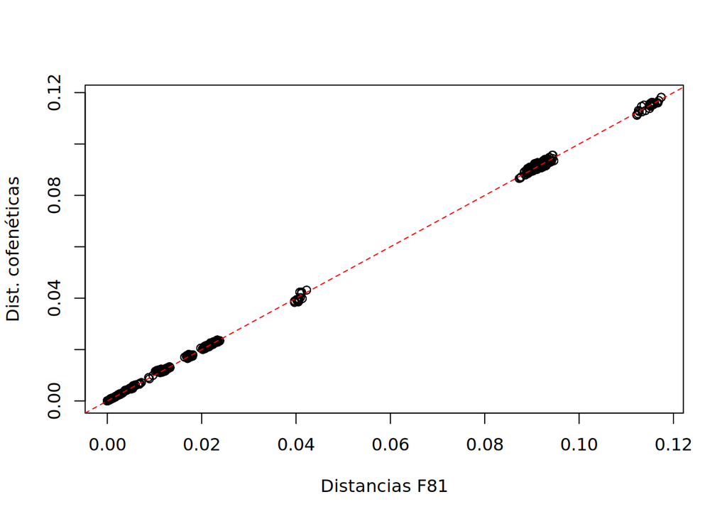

```r
# Aquí usamos las matrices como vectores:
plot(distMat, distCofen, xlab = 'Distancias F81', ylab = 'Dist. cofenéticas')
abline(a = 0, b = 1, col = 'red', lty = 2)
```

Al representar ambas matrices, se aprecia claramente la relación lineal entre sus puntos y cómo se superponen a la recta de referencia x=y, por lo que podemos concluir que los datos de ambas son prácticamente iguales.

# Limpieza o filtrado del alineamiento

Las distancias crudas, como número de diferencias, nos pueden informar de la presencia de pares de secuencias idénticas. Podríamos dejarlas, pero algunos de los métodos que usaremos a continuación pueden generar errores, por ejemplo cuando dos secuencias idénticas se supone que pertenecen a épocas diferentes. Por tanto:

```r
crudas <- dist.dna(as.DNAbin(mtdna), model = 'raw')
crudas <- as.matrix(crudas)
identicas <- which(crudas == 0 & lower.tri(crudas), arr.ind = TRUE)
# posiciones de la semimatriz inferior donde las distancias son 0:
identicas
```

```
                        row col
H.s.neandertal_KX198086  16  15
H.s.neandertal_MG025540  23  15
H.s.neandertal_MG025540  23  16
H.s.neandertal_KX198088  21  20
H.s.neandertal_KX198083  22  20
H.s.neandertal_KX198082  27  20
H.s.neandertal_KX198083  22  21
H.s.neandertal_KX198082  27  21
H.s.neandertal_KX198082  27  22
```

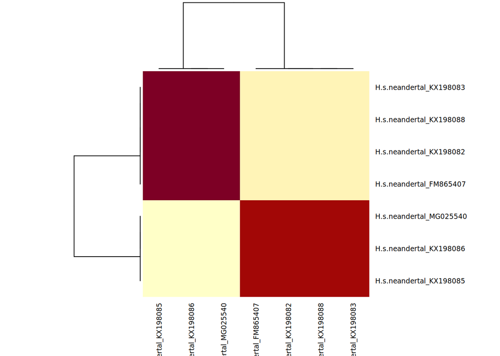

```r
repetidas <- unique(c(identicas[, 'row'], identicas[, 'col']))
heatmap(crudas[repetidas, repetidas], cexRow = 0.7, cexCol = 0.7)
```

Como vemos, las secuencias de Neandertales KX198085, KX198086 y MG025540 (todas ellas con una edad estimada de unos 40.000 años) son idénticas entre ellas; y las secuencias, también Neandertales, FM865407, KX198082, KX198088 y KX198083 también lo son.

Sin embargo, hay que tener en cuenta que la comparación ignora las posiciones en las que una secuencia contiene ambigüedades (Ns), por lo que dejaremos sólo una de cada grupo: **MG025540** y **FM865407**, ya que son las que menos ambigüedades tienen en su secuencia.

Como no conocemos una función que elimine secuencias de un objeto `phyDat`, necesitamos especificar aquellas con las que nos queremos quedar. Lo haremos así:

```r
# La exclamación ("!") invierte el valor lógico de lo que la sigue.
# La función "grepl()" produce un vector lógico con "TRUE" donde los nombres
# de las secuencias contienen alguna de esas palabras.
mtdna37 <- mtdna[! grepl('(KX198085|KX198086|KX198082|KX198088|KX198083)',
                         names(mtdna)), ]
mtdna37
```

```
37 sequences with 16603 character and 974 different site patterns.
The states are a c g t
```

**Ejercicio 6**

¿Serías capaz de crear otro conjunto de datos, `mtdna28`, que sólo contenga secuencias del género *Homo*?

Como ya tenemos `mtdna37` filtrado sin datos duplicados, partiremos de ella:

```r
mtdna28 <- mtdna37[grepl('^H.', names(mtdna37)), ]
```

Además, también nos desharemos de la secuencia del gorila, ya que es demasiado divergente y puede haber evolucionado a un ritmo diferente:

```r
mtdna36 <- mtdna37[! startsWith(names(mtdna37), 'G.gorilla'),]
```

**Aclaración**

En la sesión práctica llegamos hasta aquí. Completaré el guión porque no me gusta que el workflow de la reconstrucción se quede incompleto, pero los ejercicios restantes no están resueltos.

# Escoger el modelo de evolución molecular

Las secuencias mitocondriales proporcionan suficiente información para determinar con confianza la topología del árbol que relaciona los grupos principales. Sólo algunas regiones del árbol, como la relación exacta entre los miembros de un mismo grupo, presentan dificultad. Para estimar mejor la topología y las longitudes de las ramas, debemos usar el método de máxima verosimilitud, para el cual sí es fundamental escoger el modelo evolutivo más adecuado. Para ello usamos la funcion `modelTest()`, que devuelve un objeto de clase `modelTest`, que también puede usarse como un simple marco de datos.

```r
modelos <- modelTest(mtdna36, control = pml.control(trace = 0))
head(modelos)
```

Si tienes más de un procesador (y si tienes el paquete `parallel` instalado), puedes pedirle que los use:

```r
modelos <- modelTest(mtdna36, control = pml.control(trace = 0),
                     multicore = TRUE, mc.cores = 4)
```

Lo que hace `modelTest()` es calcular la verosimilitud de cada modelo sobre un mismo árbol. Al hacerlo, debe optimizar los parámetros de cada modelo, pero no optimiza el árbol. Sería una pérdida de tiempo no guardar los parámetros optimizados, que son un excelente punto de partida para la búsqueda del árbol más verosímil. Podemos extraer cualquiera de los modelos comparados con la función `as.pml()`:

```r
fit <- as.pml(modelos, 'GTR+G(4)+I')
fit
```

También podemos usar `as.pml()` para extraer el modelo más adecuado a los datos según alguno de los criterios disponibles (`BIC`, `AIC`, `AICc`). El motivo por el que el modelo más adecuado no es necesariamente el más verosímil es que la verosimilitud siempre será mayor para un modelo más complejo (con más parámetros), porque tiene más grados de libertad para ajustarse a los datos. Los criterios de selección penalizan los modelos con más parámetros para hacer la comparación más justa. El peligro de usar un modelo con demasiados parámetros es el de *sobreajustar* el modelo, es decir, tomar el ruido natural de los datos como algo que el modelo también debe explicar.

```r
fit <- as.pml(modelos, 'BIC')
fit
```

**Ejercicio 7**

¿Cuál es el mejor modelo para secuencias sólo del género *Homo*?

# Máxima verosimilitud

Una vez hemos seleccionado el modelo, podemos optimizar la topología del árbol, sus longitudes de ramas, y también los demás parámetros del modelo. Para ello, usaremos la función `pml_bb()`, que internamente usa las funciones `pml()` y `optim.pml()`. Podemos modular el comportamiento de `pml_bb()` (cuánta información muestra del proceso, cuántas iteraciones usa, cuándo decide que no puede mejorar el modelo…) con los parámetros definidos mediante `pml.control()`. A la función `pml_bb()` podemos proporcionarle el alineamiento (objeto de clase `phyDat`) y el nombre del modelo de evolución molecular, o bien un objeto de clase `modelTest`, de donde toma automáticamente el alineamiento y el modelo con un valor de BIC (*Bayesian Information Criterion*) más bajo.

```r
mt_ml <- pml_bb(modelos,
                control = pml.control(trace = 0))
```

El objeto `mt_ml`, de clase `pml`, *contiene* el árbol (`mt_ml$tree`), además de los parámetros optimizados del modelo. Antes de ver el árbol, echémosle un vistazo al modelo ajustado, para ver cuánto se aparta del que habíamos ajustado con `modelTest()`:

```r
mt_ml
```

```r
plot(mt_ml, align.tip.label = TRUE, main = 'Árbol más verosímil')
```

**Ejercicio 8**

- El árbol no está enraizado. Como las secuencias no son todas de la misma época, utiliza `rtt()` para situar la raíz en el punto más compatible con la hipótesis de reloj molecular.
- ¿Podrías obtener el árbol más verosímil para el subconjunto de secuencias del género *Homo*?

# Con datación de puntas (*tip dating*)

El método de máxima verosimilitud genera árboles no enraizados por defecto, como consecuencia de la reversibilidad temporal. En esos árboles las longitudes de ramas son el número esperado de sustituciones por sitio, sin ninguna referencia explícita al tiempo. Pero cuando no todas las secuencias son *isócronas*, podemos usar la información de sus edades para constreñir la búsqueda del árbol más verosímil. Al usar las edades de las secuencias, estamos asumiendo un reloj molecular: una relación constante entre el tiempo y el número esperado de sustituciones acumuladas. Entonces, la posición de la raíz afecta la verosimilitud y el resultado es un árbol enraizado.

```r
# Habíamos creado el vector "fechas", pero incluye al gorila.
fechas36 <- fechas[names(mtdna36)]
mt_ml_clock <- pml_bb(modelos,
                      method = 'tipdated',
                      tip.dates = fechas36, rearrangement = 'NNI',
                      control = pml.control(trace = 0))

mt_ml_clock
```

```r
plot(mt_ml_clock, align.tip.label = TRUE)
```

**Ejercicio 9**

- ¿Cuál es la tasa de mutación global estimada?
- ¿En qué unidades està expresada?
- ¿Cuánto tiempo dice el árbol que divergimos de los chimpancés? (Puedes usar la función `cophenetic()`, puesto que en el árbol datado las longitudes de las ramas están en años).

# Estimación de edades

Las edades de las secuencias aportan información sobre el reloj molecular en la medida en que se echen de menos las mutaciones que dejaron de acumularse en las secuencias arcaicas. Esta información puede ser muy útil en filogenias de virus de ARN muestreados a lo largo de los años. Pero en una filogenia de millones de años, la poca información de las puntas no es suficiente para datar con exactitud las divergencias antiguas. Hay otras estrategias. Podríamos fijar una tasa de mutación conocida y estimar sólo los otros parámetros. Alternativamente, podemos dar la fecha de algún nodo interno para ayudar a calibrar el reloj. Por ejemplo, supondremos que el ancestro común más reciente entre humanos y chimpancés vivió hace 6.5 millones de años.

Esta información se la proporcionamos a la función `estimate.dates()` mediante un vector de fechas o edades de las secuencias que incluya no sólo las hojas del árbol sino también los nodos internos, o al menos aquellos de los que conocemos la edad. El vector debe tener tantos componentes como nodos internos y hojas tiene el árbol, con valores `NA` en las edades desconocidas. Para saber en qué orden están numerados los nodos, podemos ejecutar lo siguiente:

```r
mt_ml_rtt <- rtt(mt_ml$tree, fechas36)
plot(mt_ml_rtt, align.tip.label = TRUE)
nodelabels()
```

Como suele suceder, la raíz (en los árboles enraizados) es el nodo que sigue a las hojas, es decir el 37, porque los 36 primeros números son las puntas.

```r
fechasNodos <- c(fechas36, -6500000, rep(NA, 34))
fechasEstimadas <- estimate.dates(mt_ml_rtt, fechasNodos)
tasaEstimada <- estimate.mu(mt_ml_rtt, fechasNodos)
# Creamos una copia del árbol...
mt_ml_años <- mt_ml_rtt
# ...y actualizamos las longitudes de sus ramas como la resta
# entre las fechas de los nodos que conectan:
mt_ml_años$edge.length <- fechasEstimadas[mt_ml_años$edge[,2]] -
                          fechasEstimadas[mt_ml_años$edge[,1]]
plot(mt_ml_años)
axisPhylo()
```

```r
tasaEstimada
```

# Apéndice

| Especie | Nº de acceso | Edad (años) | Referencia | Nombre |
| --- | --- | --- | --- | --- |
| H.heidelbergensis | NC_023100 | 400.000 | Meyer et al. (2013) | - |
| H.s.denisova | NC_013993 | 30.000-48.000 | Krause et al. (2010) | Denisova 3 (falange) |
| H.s.denisova | FR695060 | >50.000? | Reich et al. (2010) | Denisova 4 (molar) |
| H.s.denisova | KX663333 | >100.000 | Slon et al. (2017) | Denisova 2 (dent) |
| H.s.denisova | KT780370 | 110.000? | Sawyer et al. (2015) | Denisova 8 (molar) |
| H.s.neandertal | KX198085 | 32.697-46.942 | Posth et al. (2017) | GoyetQ374a-1 |
| H.s.neandertal | KX198086 | 33.134-47.057 | Posth et al. (2017) | GoyetQ305-7 |
| H.s.neandertal | MG025538 | 37.880-39.150 | Hajdinjak et al. (2018) | Spy-94a |
| H.s.neandertal | NC_011137 | 38.310 | Green et al. (2008) | Vindija 33.16 |
| H.s.neandertal | FM865409 | 39.000 | Briggs et al. (2009) | Sidron 1253 |
| H.s.neandertal | FM865407 | 40.000 | Briggs et al. (2009) | Feldhofer 1 |
| H.s.neandertal | KX198088 | 40.620-41.800 | Rougier et al. (2016) | GoyetQ57-2 |
| H.s.neandertal | KX198083 | 41.960-42.900 | Rougier et al. (2016) | GoyetQ57-3 |
| H.s.neandertal | MG025540 | 42.080-43.000 | Hajdinjak et al. (2018) | GoyetQ56-1 |
| H.s.neandertal | MG025536 | 42.720-43.740 | Hajdinjak et al. (2018) | Les Cottés Z4-1514 |
| H.s.neandertal | MG025537 | 42.960-44.600 | Hajdinjak et al. (2018) | Mezmaiskaya2 |
| H.s.neandertal | KX198087 | 43.430-45.150 | Rougier et al. (2016) | GoyetQ305-4 |
| H.s.neandertal | KX198082 | 43.910-45.630 | Rougier et al. (2016) | GoyetQ57-1 |
| H.s.neandertal | FM865408 | 49.000 | Briggs et al. (2009) | Feldhofer 2 |
| H.s.neandertal | KU131206 | >50.000 | Brown et al. (2016) | DC1227 |
| H.s.neandertal | KF982693 | 56.213-109.290 | Posth et al. (2017) | Okladnikov2 |
| H.s.neandertal | FM865411 | 60.000-70.000 | Briggs et al. (2009) | Mezmaiskaya1 |
| H.s.neandertal | KY751400 | 62.013-182.560 | Posth et al. (2017) | HST |
| H.s.neandertal | MK033602 | 90.900-130.000 | Douka et al. (2019) | Denisova15 |

# Información de la sesión